# Credit Risk Classification with Numeric and Categorical Attributes: Exploring Cost Matrix Impact

## Cost Complexity Post Pruning

```python
clf = DecisionTreeClassifier(random_state=1)
path = clf.cost_complexity_pruning_path(X_train, y_train)
ccp_alphas, impurities = path.ccp_alphas, path.impurities
```

```python
pd.DataFrame(path)
```

|  | ccp_alphas | impurities |
| --- | --- | --- |
| 0 | 0.000000 | 0.000000 |
| 1 | 0.000940 | 0.002819 |
| 2 | 0.001224 | 0.005268 |
| 3 | 0.001250 | 0.007768 |
| 4 | 0.001250 | 0.010268 |
| ... | ... | ... |
| 73 | 0.005618 | 0.335998 |
| 74 | 0.007117 | 0.357350 |
| 75 | 0.011122 | 0.368471 |
| 76 | 0.014366 | 0.382838 |
| 77 | 0.041668 | 0.424506 |

78 rows × 2 columns

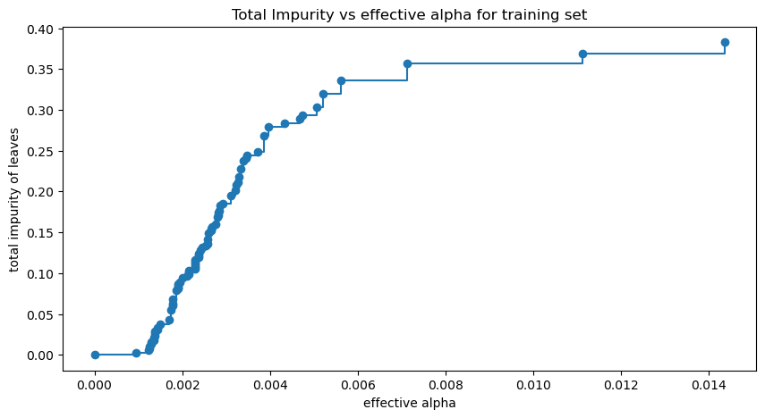

```python
fig, ax = plt.subplots(figsize=(10,5))
ax.plot(ccp_alphas[:-1], impurities[:-1], marker='o', drawstyle="steps-post")
ax.set_xlabel("effective alpha")
ax.set_ylabel("total impurity of leaves")
ax.set_title("Total Impurity vs effective alpha for training set")
plt.show()
```

```python
clfs = []
for ccp_alpha in ccp_alphas:
    clf = DecisionTreeClassifier(random_state=1, ccp_alpha=ccp_alpha)
    clf.fit(X_train, y_train)
    clfs.append(clf)
print("Number of nodes in the last tree is: {} with ccp_alpha: {}".format(
      clfs[-1].tree_.node_count, ccp_alphas[-1]))
```

```
Number of nodes in the last tree is: 1 with ccp_alpha: 0.041668413944741134
```

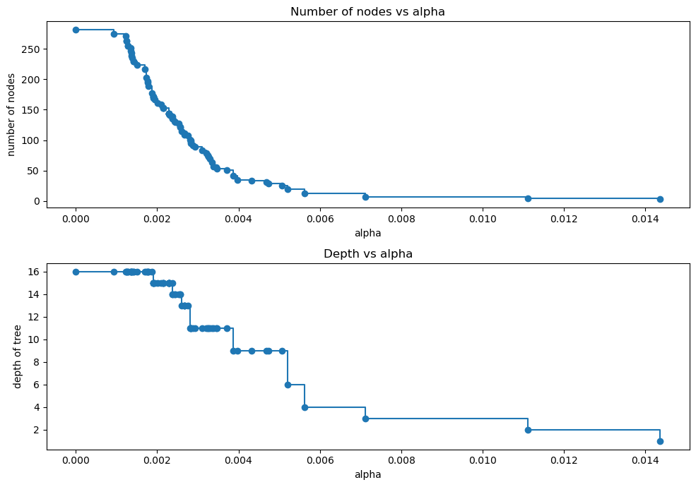

```python
clfs = clfs[:-1]
ccp_alphas = ccp_alphas[:-1]

node_counts = [clf.tree_.node_count for clf in clfs]
depth = [clf.tree_.max_depth for clf in clfs]
fig, ax = plt.subplots(2, 1,figsize=(10,7))
ax[0].plot(ccp_alphas, node_counts, marker='o', drawstyle="steps-post")
ax[0].set_xlabel("alpha")
ax[0].set_ylabel("number of nodes")
ax[0].set_title("Number of nodes vs alpha")
ax[1].plot(ccp_alphas, depth, marker='o', drawstyle="steps-post")
ax[1].set_xlabel("alpha")
ax[1].set_ylabel("depth of tree")
ax[1].set_title("Depth vs alpha")
fig.tight_layout()
```

### Accuracy vs Alpha

```python
train_scores = [clf.score(X_train, y_train) for clf in clfs]
test_scores = [clf.score(X_test, y_test) for clf in clfs]
```

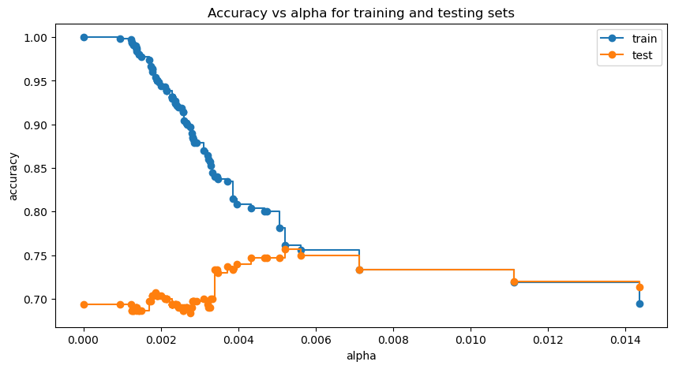

```python
fig, ax = plt.subplots(figsize=(10,5))
ax.set_xlabel("alpha")
ax.set_ylabel("accuracy")
ax.set_title("Accuracy vs alpha for training and testing sets")
ax.plot(ccp_alphas, train_scores, marker='o', label="train",
        drawstyle="steps-post")
ax.plot(ccp_alphas, test_scores, marker='o', label="test",
        drawstyle="steps-post")
ax.legend()
plt.show()
```

```python
index_best_model = np.argmax(test_scores)
best_model = clfs[index_best_model]
print(best_model)
print('Training accuracy of best model: ',best_model.score(X_train, y_train))
print('Test accuracy of best model: ',best_model.score(X_test, y_test))
```

```
DecisionTreeClassifier(ccp_alpha=0.005203486535576088, random_state=1)
Training accuracy of best model:  0.7614285714285715
Test accuracy of best model:  0.7566666666666667
```

### Recall vs Alpha

```python
recall_train=[]
for clf in clfs:
    pred_train3=clf.predict(X_train)
    values_train=metrics.recall_score(y_train,pred_train3)
    recall_train.append(values_train)
```

```python
recall_test=[]
for clf in clfs:
    pred_test3=clf.predict(X_test)
    values_test=metrics.recall_score(y_test,pred_test3)
    recall_test.append(values_test)
```

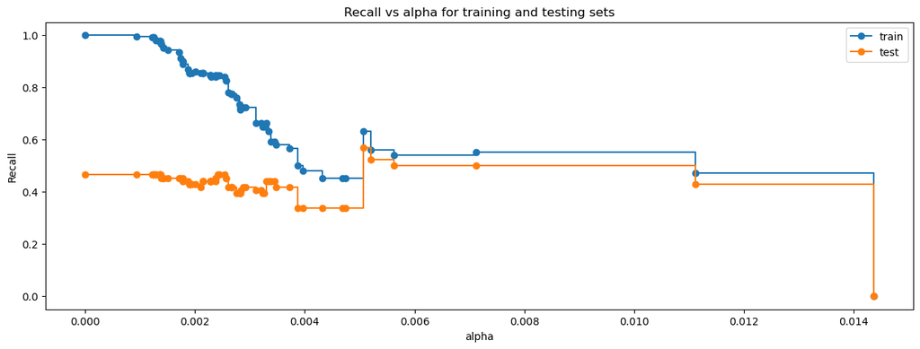

```python
fig, ax = plt.subplots(figsize=(15,5))
ax.set_xlabel("alpha")
ax.set_ylabel("Recall")
ax.set_title("Recall vs alpha for training and testing sets")
ax.plot(ccp_alphas, recall_train, marker='o', label="train",
        drawstyle="steps-post")
ax.plot(ccp_alphas, recall_test, marker='o', label="test",
        drawstyle="steps-post")
ax.legend()
plt.show()
```

### Creating the best model

```python
index_best_model = np.argmax(recall_test)
best_model = clfs[index_best_model]
print(best_model)
```

```
DecisionTreeClassifier(ccp_alpha=0.0050611694980498625, random_state=1)
```

## Confusion Matrix - post-pruned decision tree

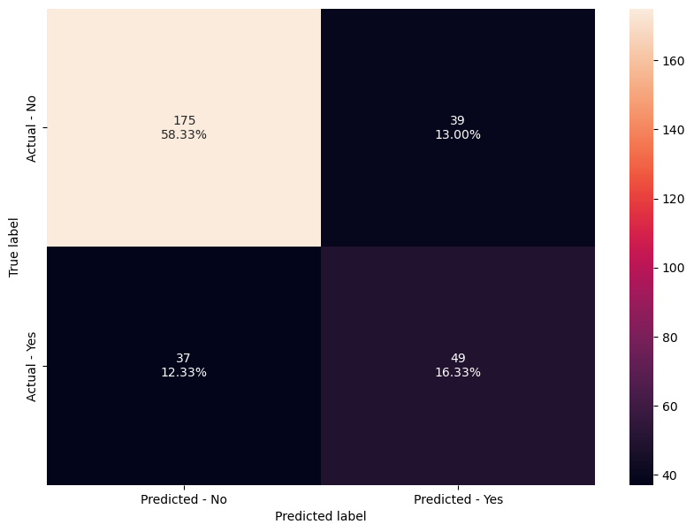

```python
confusion_matrix(best_model,y_test)
```

### Recall Scores

```python
recall_score(best_model)
```

```
Recall on training set :  0.6308411214953271
Recall on test set :  0.5697674418604651
```

## Visualizing the Decision Tree

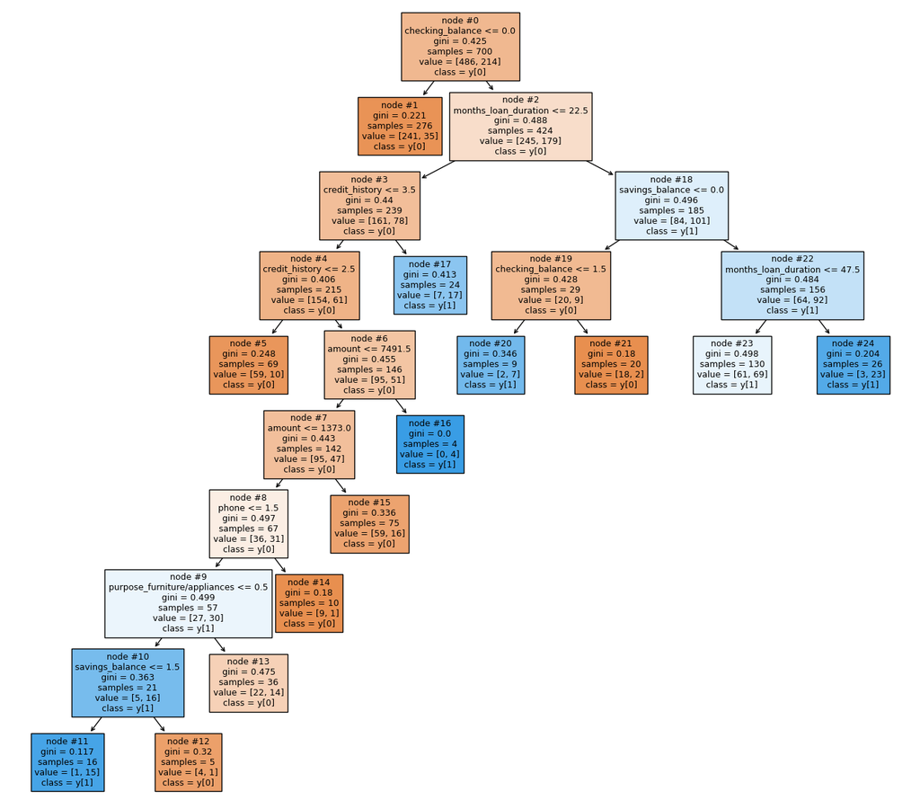

```python
plt.figure(figsize=(17,15))

tree.plot_tree(best_model,feature_names=feature_names,filled=True,fontsize=9,node_ids=True,class_names=True)
plt.show()
```

### Text Report for Decision Tree

```python
print(tree.export_text(best_model,feature_names=feature_names,show_weights=True))
```

```
|--- checking_balance <= 0.00
|   |--- weights: [241.00, 35.00] class: 0
|--- checking_balance >  0.00
|   |--- months_loan_duration <= 22.50
|   |   |--- credit_history <= 3.50
|   |   |   |--- credit_history <= 2.50
|   |   |   |   |--- weights: [59.00, 10.00] class: 0
|   |   |   |--- credit_history >  2.50
|   |   |   |   |--- amount <= 7491.50
|   |   |   |   |   |--- amount <= 1373.00
|   |   |   |   |   |   |--- phone <= 1.50
|   |   |   |   |   |   |   |--- purpose_furniture/appliances <= 0.50
|   |   |   |   |   |   |   |   |--- savings_balance <= 1.50
|   |   |   |   |   |   |   |   |   |--- weights: [1.00, 15.00] class: 1
|   |   |   |   |   |   |   |   |--- savings_balance >  1.50
|   |   |   |   |   |   |   |   |   |--- weights: [4.00, 1.00] class: 0
|   |   |   |   |   |   |   |--- purpose_furniture/appliances >  0.50
|   |   |   |   |   |   |   |   |--- weights: [22.00, 14.00] class: 0
|   |   |   |   |   |   |--- phone >  1.50
|   |   |   |   |   |   |   |--- weights: [9.00, 1.00] class: 0
|   |   |   |   |   |--- amount >  1373.00
|   |   |   |   |   |   |--- weights: [59.00, 16.00] class: 0
|   |   |   |   |--- amount >  7491.50
|   |   |   |   |   |--- weights: [0.00, 4.00] class: 1
|   |   |--- credit_history >  3.50
|   |   |   |--- weights: [7.00, 17.00] class: 1
|   |--- months_loan_duration >  22.50
|   |   |--- savings_balance <= 0.00
|   |   |   |--- checking_balance <= 1.50
|   |   |   |   |--- weights: [2.00, 7.00] class: 1
|   |   |   |--- checking_balance >  1.50
|   |   |   |   |--- weights: [18.00, 2.00] class: 0
|   |   |--- savings_balance >  0.00
|   |   |   |--- months_loan_duration <= 47.50
|   |   |   |   |--- weights: [61.00, 69.00] class: 1
|   |   |   |--- months_loan_duration >  47.50
|   |   |   |   |--- weights: [3.00, 23.00] class: 1
```

### Gini importance of the features

```python
print (pd.DataFrame(best_model.feature_importances_, columns = ["Imp"], index = X_train.columns).sort_values(by = 'Imp', ascending = False))
```

```
                                   Imp
checking_balance              0.411788
months_loan_duration          0.182828
credit_history                0.138164
savings_balance               0.094024
amount                        0.093092
purpose_furniture/appliances  0.043586
phone                         0.036518
job_skilled                   0.000000
job_management                0.000000
purpose_renovations           0.000000
other_credit_none             0.000000
other_credit_bank             0.000000
housing_rent                  0.000000
housing_own                   0.000000
job_unemployed                0.000000
housing_other                 0.000000
other_credit_store            0.000000
purpose_car0                  0.000000
purpose_education             0.000000
purpose_car                   0.000000
purpose_business              0.000000
dependents                    0.000000
existing_loans_count          0.000000
age                           0.000000
years_at_residence            0.000000
percent_of_income             0.000000
employment_duration           0.000000
job_unskilled                 0.000000
```

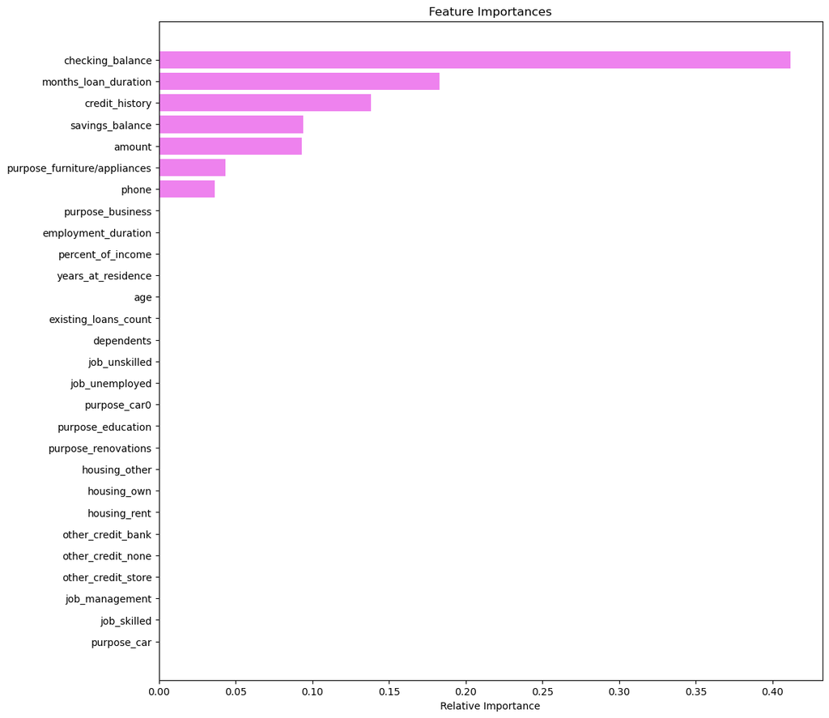

```python
importances = best_model.feature_importances_
indices = np.argsort(importances)

plt.figure(figsize=(12,12))
plt.title('Feature Importances')
plt.barh(range(len(indices)), importances[indices], color='violet', align='center')
plt.yticks(range(len(indices)), [feature_names[i] for i in indices])
plt.xlabel('Relative Importance')
plt.show()
```

## Comparing all the decision tree models

```python
comparison_frame = pd.DataFrame({'Model':['Initial decision tree model','Decision tree with restricted maximum depth','Decision treee with hyperparameter tuning',
                                         'Decision tree with post-pruning'], 'Train_Recall':[1,0.53,0.51,0.63], 'Test_Recall':[0.46,0.46,0.46,0.56]})
comparison_frame
```

|  | Model | Train_Recall | Test_Recall |
| --- | --- | --- | --- |
| 0 | Initial decision tree model | 1.00 | 0.46 |
| 1 | Decision tree with restricted maximum depth | 0.53 | 0.46 |
| 2 | Decision treee with hyperparameter tuning | 0.51 | 0.46 |
| 3 | Decision tree with post-pruning | 0.63 | 0.56 |

## Conclusion

- The Decision tree with post-pruning had the highest recall of all the previous test.
- We can see the importance of some of the features such as credit history, checking balance and duration of loan in months are some of the most important features that predict the defaulting of a client or not.

## Recommendations

### Here are some of the columns that I would have liked to add to the database.

Debt-to-Income Ratio: Calculated as the ratio of total monthly debt payments to gross monthly income, this metric offers a snapshot of the individual's debt burden relative to their income.

Credit Score: A numerical representation of an individual's creditworthiness, which can be derived from their credit history and other financial behaviors.

Employment Type: Specifies whether the individual is employed full-time, part-time, self-employed, or unemployed, providing further context about their income stability.

Education Level: Indicates the individual's level of education, which may correlate with income level and financial responsibility.

Geographic Location: Information about the individual's geographic location can provide insights into regional economic factors and cost of living.

Financial Assets: Details about other financial assets owned by the individual, such as investments, real estate, or retirement accounts.

Financial Reserves: Indicates whether the individual has emergency funds or savings set aside for unexpected expenses.